# maftools : Summarize, Analyze and Visualize MAF Files

Anand Mayakonda

2025-10-20

[figure not shown]

# 1 Introduction

With advances in Cancer Genomics, [Mutation Annotation Format](https://docs.gdc.cancer.gov/Data/File_Formats/MAF_Format/) (MAF) is being widely accepted and used to store somatic variants detected. [The Cancer Genome Atlas](http://cancergenome.nih.gov) Project has sequenced over 30 different cancers with sample size of each cancer type being over 200. [Resulting data](https://wiki.nci.nih.gov/display/TCGA/TCGA+MAF+Files) consisting of somatic variants are stored in the form of [Mutation Annotation Format](https://docs.gdc.cancer.gov/Data/File_Formats/MAF_Format/). This package attempts to summarize, analyze, annotate and visualize MAF files in an efficient manner from either TCGA sources or any in-house studies as long as the data is in MAF format.

## 1.1 Citation

# 2 Generating MAF files

- For VCF files or simple tabular files, easy option is to use vcf2maf utility which will annotate VCFs, prioritize transcripts, and generates an MAF. Recent updates to gatk has also enabled [funcotator](https://gatk.broadinstitute.org/hc/en-us/articles/360035889931-Funcotator-Information-and-Tutorial) to genrate MAF files.
- If you’re using [ANNOVAR](http://annovar.openbioinformatics.org/en/latest/) for variant annotations, maftools has a handy function `annovarToMaf` for converting tabular annovar outputs to MAF.

# 3 MAF field requirements

MAF files contain many fields ranging from chromosome names to cosmic annotations. However most of the analysis in maftools uses following fields.

- Mandatory fields: **Hugo_Symbol, Chromosome, Start_Position, End_Position, Reference_Allele, Tumor_Seq_Allele2, Variant_Classification, Variant_Type and Tumor_Sample_Barcode**.
- Recommended optional fields: non MAF specific fields containing VAF (Variant Allele Frequency) and amino acid change information.

# 4 Installation

# 5 Overview of the package

maftools functions can be categorized into mainly Visualization and Analysis modules. Each of these functions and a short description is summarized as shown below. Usage is simple, just read your MAF file with `read.maf` (along with copy-number data if available) and pass the resulting MAF object to the desired function for plotting or analysis.

[figure not shown]

Besides the MAF files, maftools also facilitates processing of BAM files. Please refer to below vignettes and sections to learn more.

# 6 Reading and summarizing maf files

## 6.1 Required input files

- an MAF file - can be gz compressed. Required.
- an optional but recommended clinical data associated with each sample/Tumor_Sample_Barcode in MAF.
- an optional copy number data if available. Can be GISTIC output or a custom table containing sample names, gene names and copy-number status (`Amp` or `Del`).

## 6.2 Reading MAF files.

```r
library(maftools)
```

```r
#path to TCGA LAML MAF file
laml.maf = system.file('extdata', 'tcga_laml.maf.gz', package = 'maftools')
#clinical information containing survival information and histology. This is optional
laml.clin = system.file('extdata', 'tcga_laml_annot.tsv', package = 'maftools')

laml = read.maf(maf = laml.maf, clinicalData = laml.clin)
```

```
## -Reading
## -Validating
## -Silent variants: 475
## -Summarizing
## -Processing clinical data
## -Finished in 0.260s elapsed (0.210s cpu)
```

## 6.3 MAF object

Summarized MAF file is stored as an MAF object. MAF object contains main maf file, summarized data and any associated sample annotations.

There are accessor methods to access the useful slots from MAF object.

```r
#Typing laml shows basic summary of MAF file.
laml
```

```
## An object of class  MAF
##                    ID          summary  Mean Median
##                <char>           <char> <num>  <num>
##  1:        NCBI_Build               37    NA     NA
##  2:            Center genome.wustl.edu    NA     NA
##  3:           Samples              193    NA     NA
##  4:            nGenes             1241    NA     NA
##  5:   Frame_Shift_Del               52 0.269      0
##  6:   Frame_Shift_Ins               91 0.472      0
##  7:      In_Frame_Del               10 0.052      0
##  8:      In_Frame_Ins               42 0.218      0
##  9: Missense_Mutation             1342 6.953      7
## 10: Nonsense_Mutation              103 0.534      0
## 11:       Splice_Site               92 0.477      0
## 12:             total             1732 8.974      9
```

```r
#Shows sample summry.
getSampleSummary(laml)
#Shows gene summary.
getGeneSummary(laml)
#shows clinical data associated with samples
getClinicalData(laml)
#Shows all fields in MAF
getFields(laml)
#Writes maf summary to an output file with basename laml.
write.mafSummary(maf = laml, basename = 'laml')
```

# 7 Visualization

## 7.1 Plotting MAF summary.

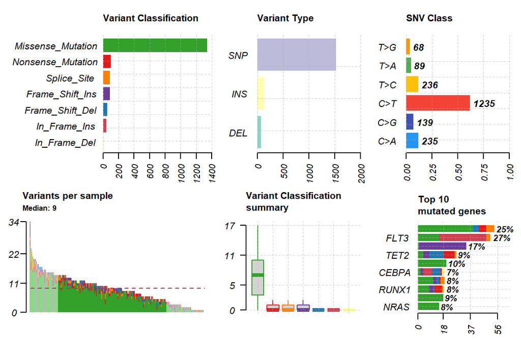

```r
plotmafSummary(maf = laml, rmOutlier = TRUE, addStat = 'median', dashboard = TRUE, titvRaw = FALSE)
```

Use `mafbarplot` for a minimal barplot of mutated genes.

## 7.2 Oncoplots

### 7.2.1 Drawing oncoplots

Better representation of maf file can be shown as oncoplots, also known as **waterfall plots**.

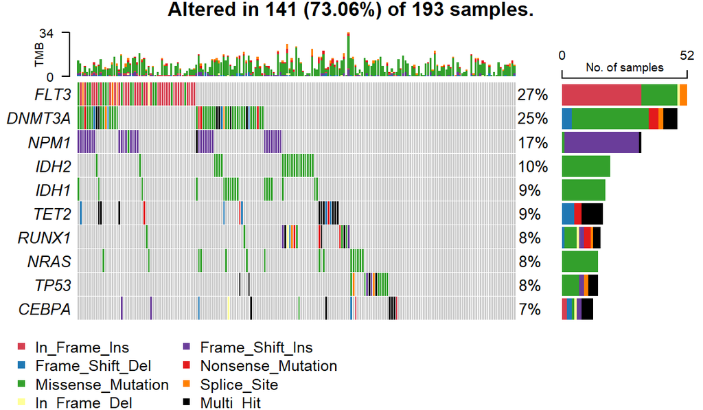

```r
#oncoplot for top ten mutated genes.
oncoplot(maf = laml, top = 10)
```

NOTE: Variants annotated as `Multi_Hit` are those genes which are mutated more than once in the same sample.

## 7.3 Transition and Transversions.

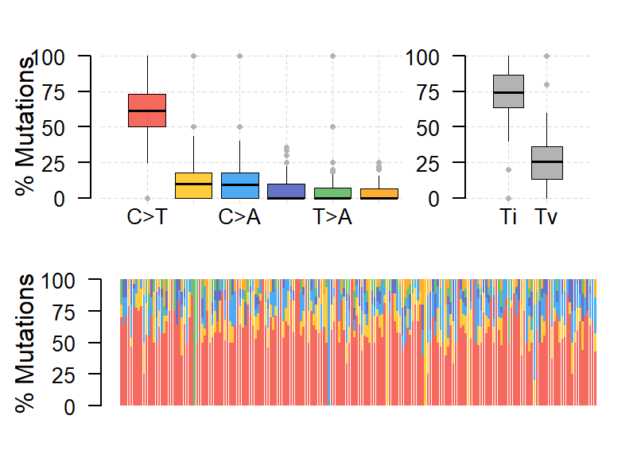

```r
laml.titv = titv(maf = laml, plot = FALSE, useSyn = TRUE)
#plot titv summary
plotTiTv(res = laml.titv)
```

## 7.4 Lollipop plots for amino acid changes

### 7.4.1 MAF as an input

```
## 3 transcripts available. Use arguments refSeqID or proteinID to manually specify tx name.
```

```
##      HGNC refseq.ID protein.ID aa.length
##    <char>    <char>     <char>     <num>
## 1: DNMT3A NM_022552  NP_072046       912
## 2: DNMT3A NM_153759  NP_715640       723
## 3: DNMT3A NM_175629  NP_783328       912
```

```
## Using longer transcript NM_022552 for now.
```

```
## Removed 3 mutations for which AA position was not available
```

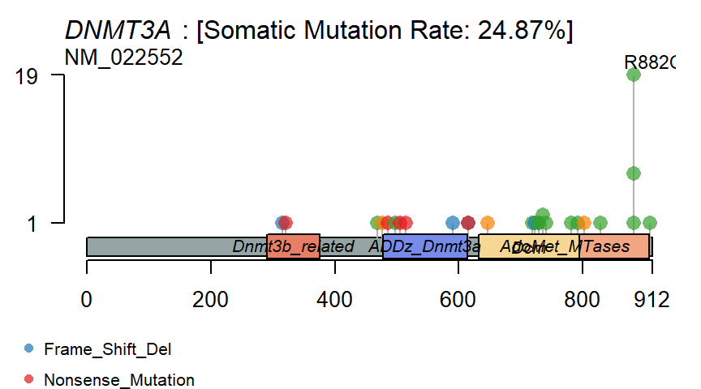

```r
#lollipop plot for DNMT3A, which is one of the most frequent mutated gene in Leukemia.
lollipopPlot(
  maf = laml,
  gene = 'DNMT3A',
  AACol = 'Protein_Change',
  showMutationRate = TRUE,
  labelPos = 882
)
```

### 7.4.2 Custom data as an input

Instead of an `MAF` a custom data can also be used for plotting.  
Input should be a two column data frame with pos and counts.

```r
#example data
my_data = data.frame(pos = sample.int(912, 15, replace = TRUE), count = sample.int(30, 15, replace = TRUE))
head(my_data)
```

```
##   pos count
## 1 396     8
## 2 301    11
## 3 879    17
## 4 302    25
## 5 568    23
## 6 374     1
```

```
## 3 transcripts available. Use arguments refSeqID or proteinID to manually specify tx name.
```

```
##      HGNC refseq.ID protein.ID aa.length
##    <char>    <char>     <char>     <num>
## 1: DNMT3A NM_022552  NP_072046       912
## 2: DNMT3A NM_153759  NP_715640       723
## 3: DNMT3A NM_175629  NP_783328       912
```

```
## Using longer transcript NM_022552 for now.
```

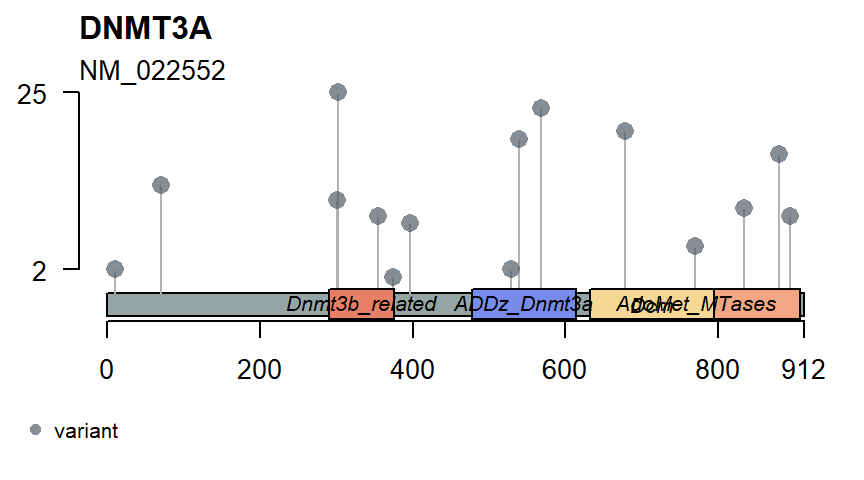

```r
lollipopPlot(data = my_data, gene = "DNMT3A")
```

General protein domains can be drawn with the function `plotProtein`

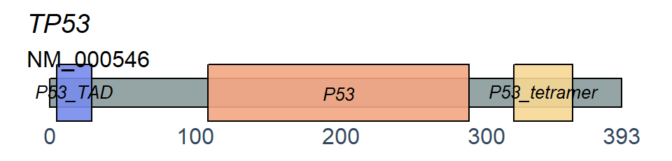

```r
plotProtein(gene = "TP53", refSeqID = "NM_000546")
```

## 7.5 Rainfall plots

Cancer genomes, especially solid tumors are characterized by genomic loci with localized hyper-mutations 5. Such hyper mutated genomic regions can be visualized by plotting inter variant distance on a linear genomic scale. These plots generally called rainfall plots and we can draw such plots using `rainfallPlot`. If `detectChangePoints` is set to TRUE, `rainfall` plot also highlights regions where potential changes in inter-event distances are located.

注： 高度相关的突变簇，各突变之间距离很短，不在簇上的随机突变总体上距离很长

```r
brca <- system.file("extdata", "brca.maf.gz", package = "maftools")
brca = read.maf(maf = brca, verbose = FALSE)
```

```
## Processing TCGA-A8-A08B..
```

```
## Kataegis detected at:
```

```
##    Chromosome Start_Position End_Position nMuts Avg_intermutation_dist  Size
##         <num>          <num>        <num> <int>                  <num> <num>
## 1:          8       98129348     98133560     7               702.0000  4212
## 2:          8       98398549     98403536     9               623.3750  4987
## 3:          8       98453076     98456466     9               423.7500  3390
## 4:          8      124090377    124096810    22               306.3333  6433
## 5:         12       97436055     97439705     7               608.3333  3650
## 6:         17       29332072     29336153     8               583.0000  4081
##    Tumor_Sample_Barcode   C>G   C>T
##                  <fctr> <int> <int>
## 1:         TCGA-A8-A08B     4     3
## 2:         TCGA-A8-A08B     1     8
## 3:         TCGA-A8-A08B     1     8
## 4:         TCGA-A8-A08B     1    21
## 5:         TCGA-A8-A08B     4     3
## 6:         TCGA-A8-A08B     4     4
```

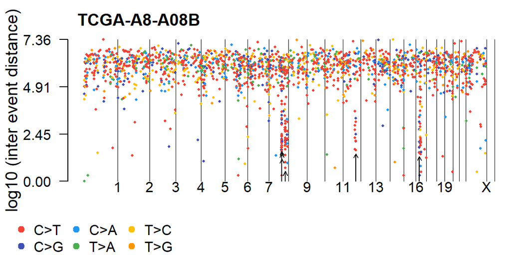

```r
rainfallPlot(maf = brca, detectChangePoints = TRUE, pointSize = 0.4)
```

## 7.6 Compare mutation load against TCGA cohorts

`tcgaCompare` uses mutation load from TCGA

```r
laml.mutload = tcgaCompare(maf = laml, cohortName = 'Example-LAML', logscale = TRUE, capture_size = 50)
```

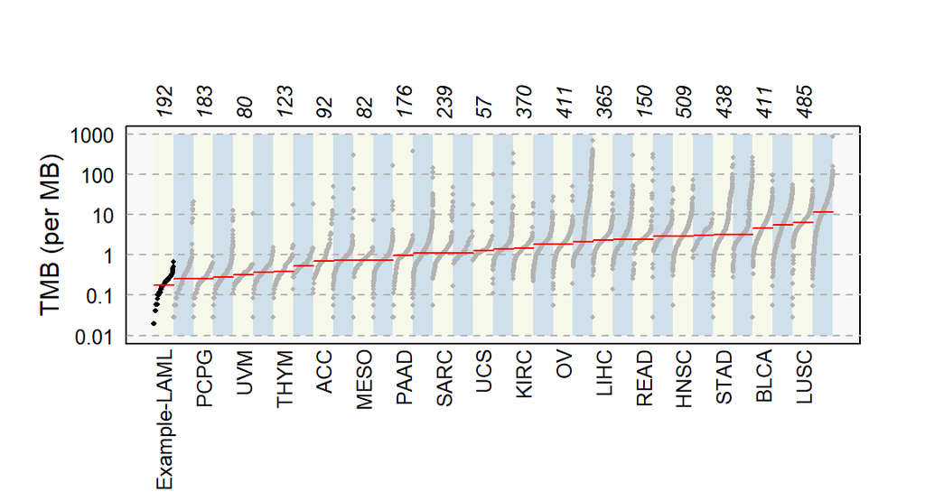

```r
# Tumor Mutation Burden, TMB << ================
```

## 7.7 Plotting VAF

This function plots Variant Allele Frequencies as a boxplot which quickly helps to estimate clonal status of top mutated genes (clonal genes usually have mean allele frequency around ~50% assuming pure sample)

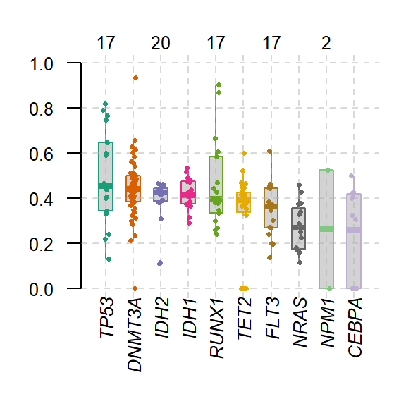

```r
plotVaf(maf = laml, vafCol = 'i_TumorVAF_WU')
```

# 8 Processing copy-number data

## 8.1 Reading and summarizing gistic output files.

We can summarize output files generated by GISTIC programme. As mentioned earlier, we need four files that are generated by GISTIC, i.e, all_lesions.conf_XX.txt, amp_genes.conf_XX.txt, del_genes.conf_XX.txt and scores.gistic, where XX is the confidence level.

```r
gistic_res_folder <- system.file("extdata", package = "maftools")
laml.gistic       = readGistic(gisticDir = gistic_res_folder, isTCGA = TRUE)
```

```
## -Processing Gistic files..
## --Processing amp_genes.conf_99.txt
## --Processing del_genes.conf_99.txt
## --Processing scores.gistic
## --Summarizing by samples
```

```r
#GISTIC object
laml.gistic
```

```
## An object of class  GISTIC
##           ID summary
##       <char>   <num>
## 1:   Samples     191
## 2:    nGenes    2622
## 3: cytoBands      16
## 4:       Amp     388
## 5:       Del   26481
## 6:     total   26869
```

Similar to MAF objects, there are methods available to access slots of GISTIC object - `getSampleSummary`, `getGeneSummary` and `getCytoBandSummary`. Summarized results can be written to output files using function `write.GisticSummary`.

## 8.2 Visualizing gistic results.

There are three types of plots available to visualize gistic results.

GISTIC（Genomic Identification of Significant Targets in Cancer）分析的结果，展示整个基因组中复发性体细胞拷贝数变异 (SCNA) 的显著性。

### 8.2.1 genome plot

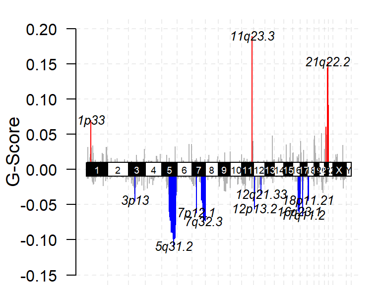

```r
gisticChromPlot(gistic = laml.gistic, markBands = "all")
```

#### 8.2.1.1 Co-gisticChromPlot

Similarly, two GISTIC objects can be plotted side-by-side for cohort comparison. In this example, the same GISTIC object is used for demonstration.

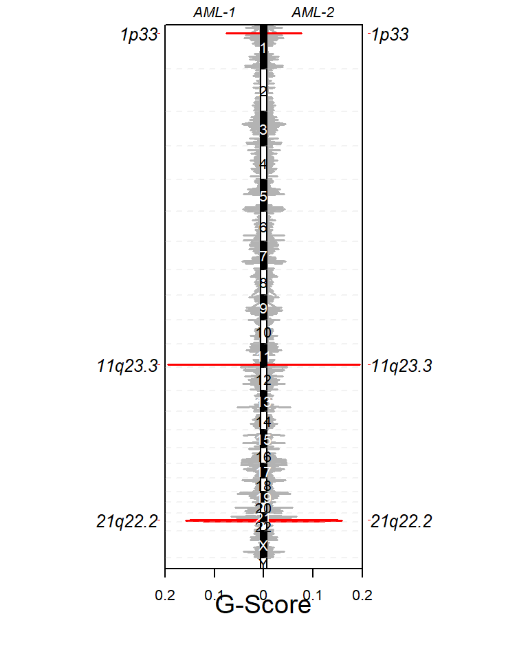

```r
coGisticChromPlot(gistic1 = laml.gistic, gistic2 = laml.gistic, g1Name = "AML-1", g2Name = "AML-2", type = 'Amp')
```

Above plot shows distribution of amplification events. Change `type = 'Del'` to plot deletions.

### 8.2.2 Bubble plot

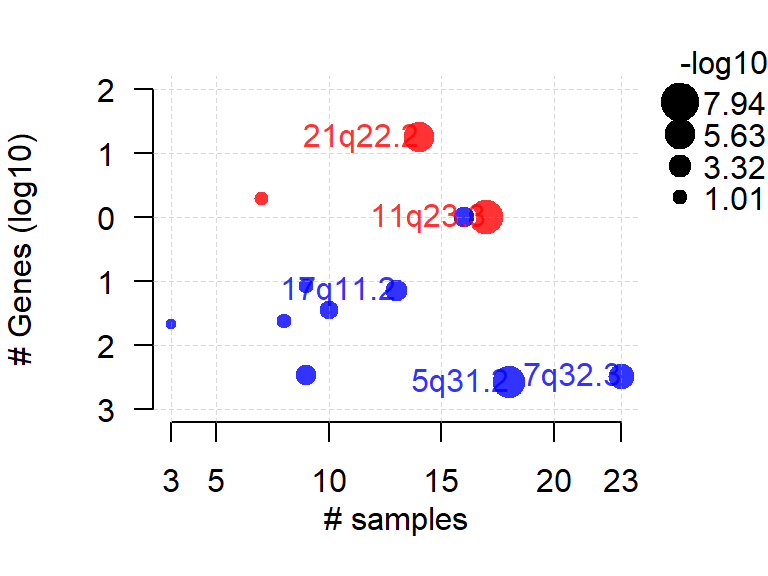

```r
gisticBubblePlot(gistic = laml.gistic)
```

### 8.2.3 oncoplot

This is similar to oncoplots except for copy number data. One can again sort the matrix according to annotations, if any. Below plot is the gistic results for LAML, sorted according to FAB classification. Plot shows that 7q deletions are virtually absent in M4 subtype where as it is widespread in other subtypes.

FAB 分类 (French-American-British Classification)： 含义：FAB 分类是一种传统的、基于形态学（细胞外观）和细胞化学染色结果的方案，主要用于对急性白血病进行分类，特别是急性髓系白血病 (AML) 和急性淋巴细胞白血病 (ALL)。 常见亚型（以 AML 为例）：M0（未分化型）、M1（髓母细胞型未成熟）、M2（髓母细胞型成熟）、M3（早幼粒细胞型）、M4（粒单核细胞型）、M5（单核细胞型）、M6（红白血病）、M7（巨核细胞型）。

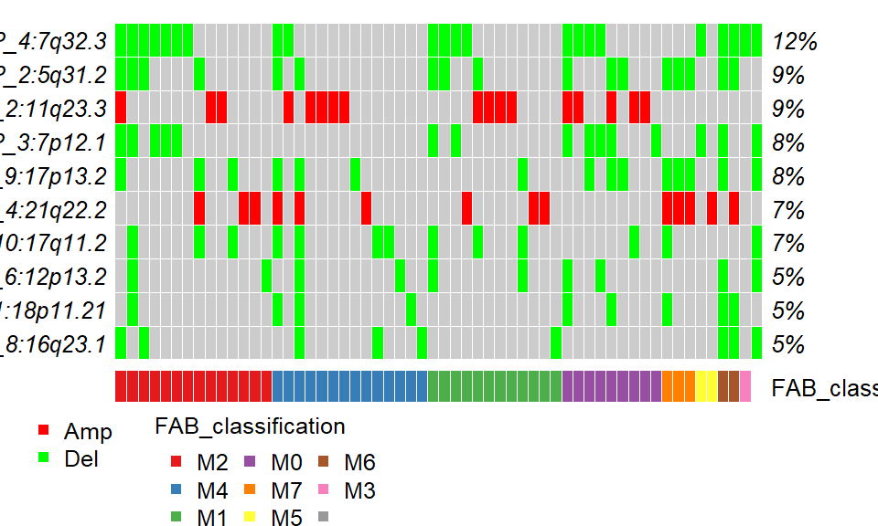

```r
gisticOncoPlot(gistic = laml.gistic, clinicalData = getClinicalData(x = laml),
               clinicalFeatures = 'FAB_classification', sortByAnnotation = TRUE,
               top = 10)
```

### 8.2.4 Visualizing CBS segments

可视化单个样本的拷贝数变异 (Copy Number Variation, CNV) 区域，这些区域是通过 CBS (Circular Binary Segmentation) 算法从原始的 DNA 测序数据（如 log2比例值）中分割出来的。

Y 轴表示测序深度在肿瘤样本与对照样本（或预设的正常拷贝数）之间的 log2 / log2 比值。

(肿瘤样本拷贝数 / 正常样本拷贝数)

Y = 0：中性拷贝数。表示该区域的拷贝数是正常的（通常假设为 2 拷贝）。 Y > 0：拷贝数增加（扩增）。例如，如果 Y≈0.58，则 Ratio ≈ 1.5 Y < 0：拷贝数减少（缺失）。例如，如果 Y≈−1.0，则 Ratio ≈ 0.5，表示 1 拷贝（单拷贝丢失）。如果Y 值更低，可能表示纯合缺失

```
## No 'tsb' specified, plot head 1 sample. Set tsb='ALL' to plot all samples.
```

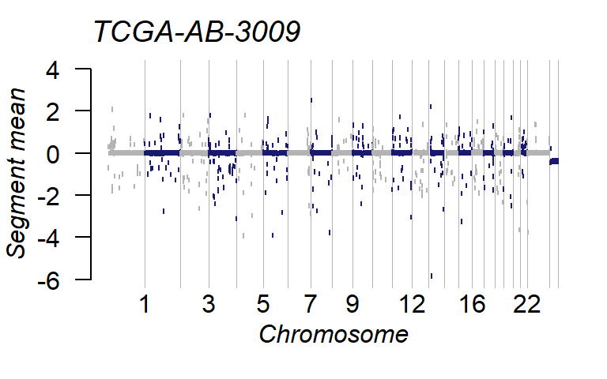

```r
tcga.ab.009.seg <- system.file("extdata", "TCGA.AB.3009.hg19.seg.txt", package = "maftools")


plotCBSsegments(cbsFile = tcga.ab.009.seg)
```

# 9 Analysis

## 9.1 Somatic Interactions

Mutually exclusive or co-occurring set of genes can be detected using `somaticInteractions` function, which performs pair-wise Fisher’s Exact test to detect such significant pair of genes.

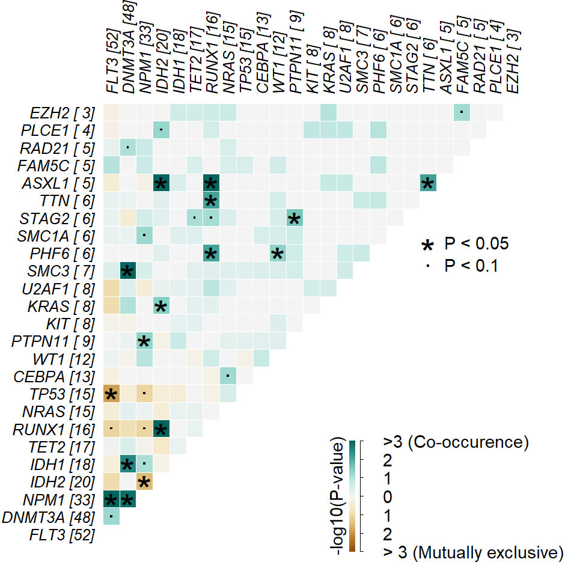

```
##       gene1  gene2       pValue oddsRatio    00    01    11    10        pAdj
##      <char> <char>        <num>     <num> <int> <int> <int> <int>       <num>
##   1:  ASXL1  RUNX1 0.0001541586 55.215541   176    12     4     1 0.003568486
##   2:   IDH2  RUNX1 0.0002809928  9.590877   164     9     7    13 0.006055880
##   3:   IDH2  ASXL1 0.0004030636 41.077327   172     1     4    16 0.008126283
##   4:   FLT3   NPM1 0.0009929836  3.763161   125    16    17    35 0.018664260
##   5:   SMC3 DNMT3A 0.0010451985 20.177713   144    42     6     1 0.018664260
##  ---
## 296:  PLCE1  ASXL1 1.0000000000  0.000000   184     5     0     4 1.000000000
## 297:  RAD21  FAM5C 1.0000000000  0.000000   183     5     0     5 1.000000000
## 298:  PLCE1  FAM5C 1.0000000000  0.000000   184     5     0     4 1.000000000
## 299:  PLCE1  RAD21 1.0000000000  0.000000   184     5     0     4 1.000000000
## 300:   EZH2  PLCE1 1.0000000000  0.000000   186     4     0     3 1.000000000
##                   Event         pair event_ratio
##                  <char>       <char>      <char>
##   1:       Co_Occurence ASXL1, RUNX1        4/13
##   2:       Co_Occurence  IDH2, RUNX1        7/22
##   3:       Co_Occurence  ASXL1, IDH2        4/17
##   4:       Co_Occurence   FLT3, NPM1       17/51
##   5:       Co_Occurence DNMT3A, SMC3        6/43
##  ---
## 296: Mutually_Exclusive ASXL1, PLCE1         0/9
## 297: Mutually_Exclusive FAM5C, RAD21        0/10
## 298: Mutually_Exclusive FAM5C, PLCE1         0/9
## 299: Mutually_Exclusive PLCE1, RAD21         0/9
## 300: Mutually_Exclusive  EZH2, PLCE1         0/7
```

```r
#exclusive/co-occurance event analysis on top 10 mutated genes.
somaticInteractions(maf = laml, top = 25, pvalue = c(0.05, 0.1))
```

## 9.2 Detecting cancer driver genes based on positional clustering

```r
laml.sig = oncodrive(maf = laml, AACol = 'Protein_Change', minMut = 5, pvalMethod = 'zscore')
head(laml.sig)
```

```
##    Hugo_Symbol Frame_Shift_Del Frame_Shift_Ins In_Frame_Del In_Frame_Ins
##         <char>           <int>           <int>        <int>        <int>
## 1:        IDH1               0               0            0            0
## 2:        IDH2               0               0            0            0
## 3:        NPM1               0              33            0            0
## 4:        NRAS               0               0            0            0
## 5:       U2AF1               0               0            0            0
## 6:         KIT               1               1            0            1
##    Missense_Mutation Nonsense_Mutation Splice_Site total MutatedSamples
##                <int>             <int>       <int> <num>          <int>
## 1:                18                 0           0    18             18
## 2:                20                 0           0    20             20
## 3:                 1                 0           0    34             33
## 4:                15                 0           0    15             15
## 5:                 8                 0           0     8              8
```

[output cut: 17 more lines]

We can plot the results using `plotOncodrive`.

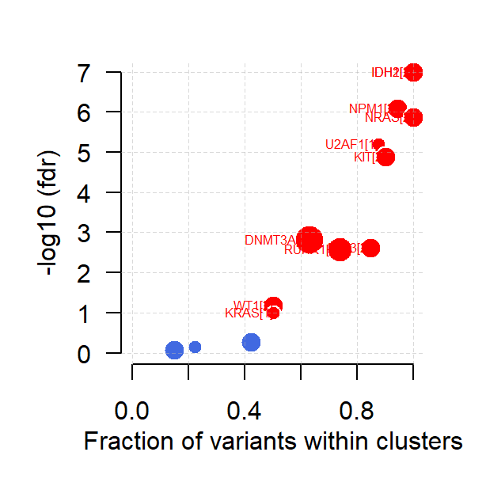

```r
plotOncodrive(res = laml.sig, fdrCutOff = 0.1, useFraction = TRUE, labelSize = 0.5)
```

## 9.3 Adding and summarizing pfam domains

maftools comes with the function `pfamDomains`, which adds pfam domain information to the amino acid changes.

```r
laml.pfam = pfamDomains(maf = laml, AACol = 'Protein_Change', top = 10)
```

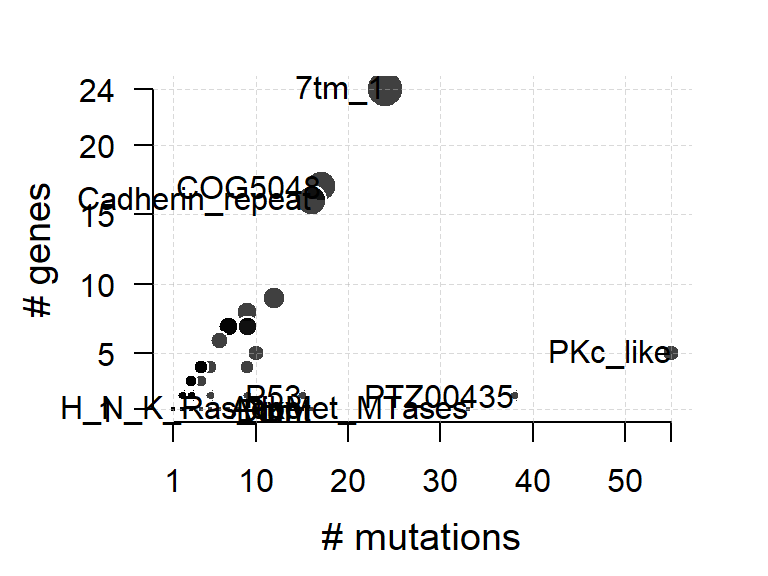

```r
#Protein summary (Printing first 7 columns for display convenience)
laml.pfam$proteinSummary[,1:7, with = FALSE]
```

```
##         HGNC AAPos Variant_Classification     N total  fraction   DomainLabel
##       <char> <num>                 <fctr> <int> <num>     <num>        <char>
##    1: DNMT3A   882      Missense_Mutation    27    54 0.5000000 AdoMet_MTases
##    2:   IDH1   132      Missense_Mutation    18    18 1.0000000      PTZ00435
##    3:   IDH2   140      Missense_Mutation    17    20 0.8500000      PTZ00435
##    4:   FLT3   835      Missense_Mutation    14    52 0.2692308      PKc_like
##    5:   FLT3   599           In_Frame_Ins    10    52 0.1923077      PKc_like
##   ---
## 1512: ZNF646   875      Missense_Mutation     1     1 1.0000000          <NA>
## 1513: ZNF687   554      Missense_Mutation     1     2 0.5000000          <NA>
## 1514: ZNF687   363      Missense_Mutation     1     2 0.5000000          <NA>
## 1515: ZNF75D     5      Missense_Mutation     1     1 1.0000000          <NA>
## 1516: ZNF827   427        Frame_Shift_Del     1     1 1.0000000          <NA>
```

```r
#Domain summary (Printing first 3 columns for display convenience)
laml.pfam$domainSummary[,1:3, with = FALSE]
```

```
##        DomainLabel nMuts nGenes
##             <char> <int>  <int>
##   1:      PKc_like    55      5
##   2:      PTZ00435    38      2
##   3: AdoMet_MTases    33      1
##   4:         7tm_1    24     24
##   5:       COG5048    17     17
##  ---
## 499:    ribokinase     1      1
## 500:   rim_protein     1      1
## 501: sigpep_I_bact     1      1
## 502:           trp     1      1
## 503:        zf-BED     1      1
```

## 9.4 Survival analysis

### 9.4.1 Mutation in any given genes

```r
#Survival analysis based on grouping of DNMT3A mutation status
mafSurvival(maf = laml, genes = 'DNMT3A', time = 'days_to_last_followup', Status = 'Overall_Survival_Status', isTCGA = TRUE)
```

```
## Looking for clinical data in annoatation slot of MAF..
```

```
## Number of mutated samples for given genes:
```

```
## DNMT3A
##     48
```

```
## Removed 11 samples with NA's
```

```
## Median survival..
```

```
##     Group medianTime     N
##    <char>      <num> <int>
## 1: Mutant        245    45
## 2:     WT        396   137
```

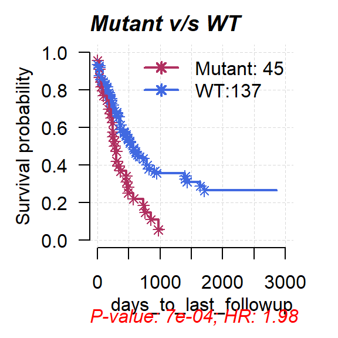

### 9.4.2 Predict genesets associated with survival

Identify set of genes which results in poor survival

```r
#Using top 20 mutated genes to identify a set of genes (of size 2) to predict poor prognostic groups
prog_geneset = survGroup(maf = laml, top = 20, geneSetSize = 2, time = "days_to_last_followup", Status = "Overall_Survival_Status", verbose = FALSE)
```

```
## Removed 11 samples with NA's
```

```r
print(prog_geneset)
```

```
##     Gene_combination P_value    hr    WT Mutant
##               <char>   <num> <num> <int>  <int>
##  1:      FLT3_DNMT3A 0.00104 2.510   164     18
##  2:      DNMT3A_SMC3 0.04880 2.220   176      6
##  3:      DNMT3A_NPM1 0.07190 1.720   166     16
##  4:      DNMT3A_TET2 0.19600 1.780   176      6
##  5:        FLT3_TET2 0.20700 1.860   177      5
##  6:        NPM1_IDH1 0.21900 0.495   176      6
##  7:      DNMT3A_IDH1 0.29300 1.500   173      9
##  8:       IDH2_RUNX1 0.31800 1.580   176      6
##  9:        FLT3_NPM1 0.53600 1.210   165     17
## 10:      DNMT3A_IDH2 0.68000 0.747   178      4
## 11:      DNMT3A_NRAS 0.99200 0.986   178      4
```

Above results show a combination (N = 2) of genes which are associated with poor survival (P < 0.05). We can draw KM curve for above results with the function `mafSurvGroup`

```r
mafSurvGroup(maf     = laml,
             geneSet = c("DNMT3A", "FLT3"),
             time    = "days_to_last_followup",
             Status  = "Overall_Survival_Status")
```

```
## Looking for clinical data in annoatation slot of MAF..
```

```
## Removed 11 samples with NA's
```

```
## Median survival..
```

```
##     Group medianTime     N
##    <char>      <num> <int>
## 1: Mutant      242.5    18
## 2:     WT      379.5   164
```

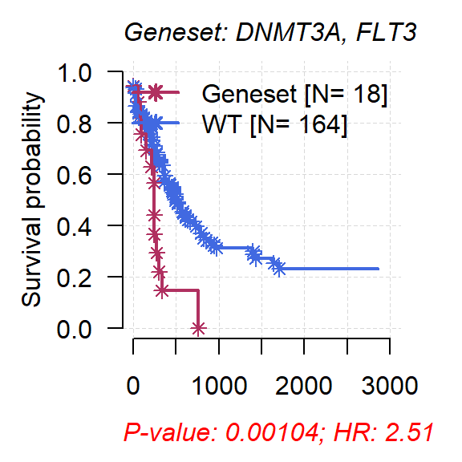

## 9.5 Comparing two cohorts (MAFs)

```r
#Primary APL MAF
primary.apl = system.file("extdata", "APL_primary.maf.gz", package = "maftools")
primary.apl = read.maf(maf = primary.apl)
#Relapse APL MAF
relapse.apl = system.file("extdata", "APL_relapse.maf.gz", package = "maftools")
relapse.apl = read.maf(maf = relapse.apl)
```

```r
#Considering only genes which are mutated in at-least in 5 samples in one of the cohort to avoid bias due to genes mutated in single sample.
pt.vs.rt <- mafCompare(m1 = primary.apl, m2 = relapse.apl, m1Name = 'Primary', m2Name = 'Relapse', minMut = 5)
print(pt.vs.rt)
```

```
## $results
##    Hugo_Symbol Primary Relapse         pval         or       ci.up      ci.low
##         <char>   <num>   <int>        <num>      <num>       <num>       <num>
## 1:         PML       1      11 1.529935e-05 0.03537381   0.2552937 0.000806034
## 2:        RARA       0       7 2.574810e-04 0.00000000   0.3006159 0.000000000
## 3:       RUNX1       1       5 1.310500e-02 0.08740567   0.8076265 0.001813280
## 4:        FLT3      26       4 1.812779e-02 3.56086275  14.7701728 1.149009169
## 5:      ARID1B       5       8 2.758396e-02 0.26480490   0.9698686 0.064804160
## 6:         WT1      20      14 2.229087e-01 0.60619329   1.4223101 0.263440988
## 7:        KRAS       6       1 4.334067e-01 2.88486293 135.5393108 0.337679367
## 8:        NRAS      15       4 4.353567e-01 1.85209500   8.0373994 0.553883512
## 9:      ARID1A       7       4 7.457274e-01 0.80869223   3.9297309 0.195710173
##         adjPval
##           <num>
## 1: 0.0001376942
## 2: 0.0011586643
## 3: 0.0393149868
## 4: 0.0407875250
## 5: 0.0496511201
## 6: 0.3343630535
## 7: 0.4897762916
## 8: 0.4897762916
## 9: 0.7457273717
##
## $SampleSummary
##     Cohort SampleSize
##     <char>      <num>
## 1: Primary        124
## 2: Relapse         58
```

### 9.5.1 Forest plots

Above results show two genes PML and RARA which are highly mutated in Relapse APL compared to Primary APL. We can visualize these results as a [forestplot](https://en.wikipedia.org/wiki/Forest_plot).

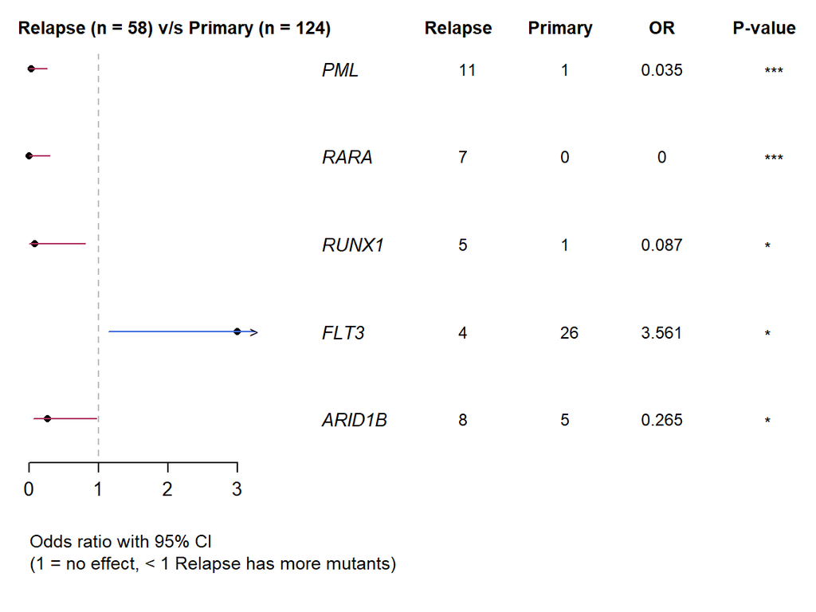

```r
forestPlot(mafCompareRes = pt.vs.rt, pVal = 0.1)
```

### 9.5.2 Co-onco plots

Another alternative way of displaying above results is by plotting two oncoplots side by side. `coOncoplot` function takes two maf objects and plots them side by side for better comparison.

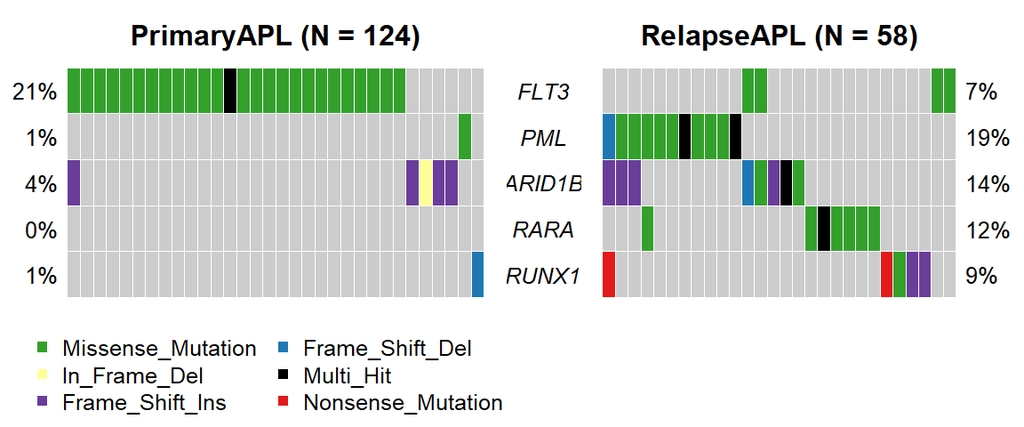

```r
genes = c("PML", "RARA", "RUNX1", "ARID1B", "FLT3")
coOncoplot(m1 = primary.apl, m2 = relapse.apl, m1Name = 'PrimaryAPL', m2Name = 'RelapseAPL', genes = genes, removeNonMutated = TRUE)
```

### 9.5.3 Co-bar plots

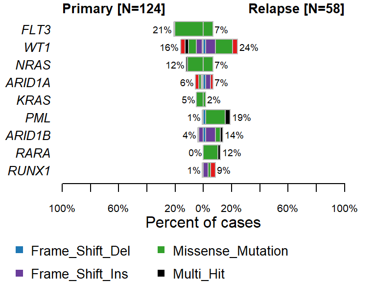

```r
coBarplot(m1 = primary.apl, m2 = relapse.apl, m1Name = "Primary", m2Name = "Relapse")
```

### 9.5.4 Lollipop plot-2 >> 棒棒糖图 (Lollipop Plot)

Along with plots showing cohort wise differences, its also possible to show gene wise differences with `lollipopPlot2` function.

含义：图上的**垂直线（棒）和顶部的圆圈（糖）**代表一个体细胞突变事件。 棒的高度：棒棒糖的高度通常表示该位点发生的突变数量（即在该氨基酸位点上发生突变的不同样本数）。棒越高，该位点越“热点”（Hotspot）。 圆圈颜色：圆圈的颜色是最重要的信息之一，它根据突变的类型进行编码。

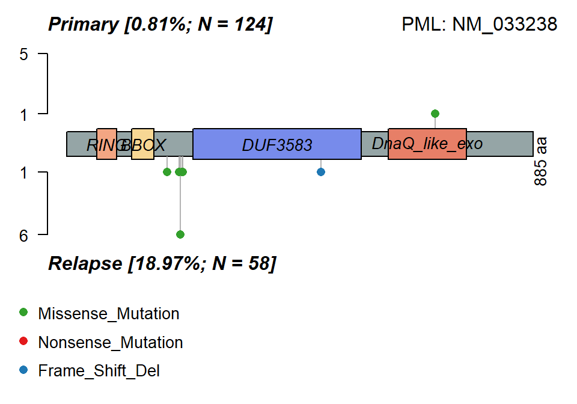

```r
lollipopPlot2(m1 = primary.apl, m2 = relapse.apl,
              gene = "PML",
              AACol1 = "amino_acid_change", AACol2 = "amino_acid_change",
              m1_name = "Primary", m2_name = "Relapse")
```

## 9.6 Clinical enrichment analysis

```r
fab.ce = clinicalEnrichment(maf = laml, clinicalFeature = 'FAB_classification')
```

```
## Sample size per factor in FAB_classification:
```

```
##
## M0 M1 M2 M3 M4 M5 M6 M7
## 19 44 44 21 39 19  3  3
##      Hugo_Symbol Feature_1 Feature_2 n_mutated_Feature1 n_mutated_Feature2
##           <char>    <char>    <char>             <char>             <char>
##   1:        FLT3        M1        M0           15 of 44            4 of 19
##   2:        FLT3        M2        M0            8 of 44            4 of 19
##   3:        FLT3        M3        M0            6 of 21            4 of 19
##   4:        FLT3        M4        M0           13 of 39            4 of 19
##   5:        FLT3        M5        M0            6 of 19            4 of 19
##  ---
## 617:         TTN      <NA>      <NA>               <NA>               <NA>
## 618:         TTN      <NA>      <NA>               <NA>               <NA>
## 619:         TTN      <NA>      <NA>               <NA>               <NA>
## 620:         TTN      <NA>      <NA>               <NA>               <NA>
```

[output cut: 27 more lines]

```r
#Results are returned as a list. Significant associations p-value < 0.05
fab.ce$groupwise_comparision[p_value < 0.05]
```

```
##    Hugo_Symbol Group1 Group2 n_mutated_group1 n_mutated_group2      p_value
##         <char> <char> <char>           <char>           <char>        <num>
## 1:        IDH1     M1   Rest         11 of 44         7 of 149 0.0002597371
## 2:        TP53     M7   Rest           3 of 3        12 of 190 0.0003857187
## 3:      DNMT3A     M5   Rest         10 of 19        38 of 174 0.0089427384
## 4:       CEBPA     M2   Rest          7 of 44         6 of 149 0.0117352110
## 5:       RUNX1     M0   Rest          5 of 19        11 of 174 0.0117436825
## 6:        NPM1     M5   Rest          7 of 19        26 of 174 0.0248582372
## 7:        NPM1     M3   Rest          0 of 21        33 of 172 0.0278630823
## 8:      DNMT3A     M3   Rest          1 of 21        47 of 172 0.0294005111
##          OR      OR_low    OR_high       fdr
##       <num>       <num>      <num>     <num>
## 1: 6.670592 2.173829026 21.9607250 0.0308575
## 2:      Inf 5.355415451        Inf 0.0308575
## 3: 3.941207 1.333635173 11.8455979 0.3757978
## 4: 4.463237 1.204699322 17.1341278 0.3757978
## 5: 5.216902 1.243812880 19.4051505 0.3757978
## 6: 3.293201 1.001404899 10.1210509 0.5880102
## 7: 0.000000 0.000000000  0.8651972 0.5880102
## 8: 0.133827 0.003146708  0.8848897 0.5880102
```

Above results shows IDH1 mutations are enriched in M1 subtype of leukemia compared to rest of the cohort. Similarly DNMT3A is in M5, RUNX1 is in M0, and so on. These are well known results and this function effectively recaptures them. One can use any sort of clincial feature to perform such an analysis. There is also a small function - `plotEnrichmentResults` which can be used to plot these results.

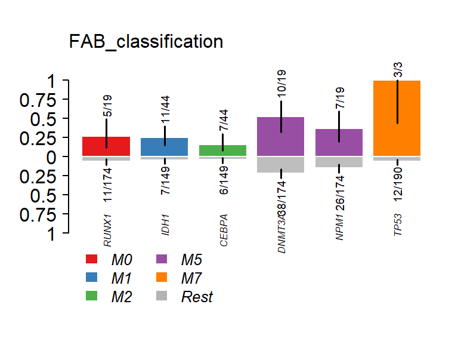

```r
plotEnrichmentResults(enrich_res = fab.ce, pVal = 0.05, geneFontSize = 0.5, annoFontSize = 0.6)
```

以下两步重要，旋转图片90度

```r
dnmt3a.dgi = drugInteractions(genes = "DNMT3A", drugs = TRUE)
```

```
## Number of claimed drugs for given genes:
##      Gene     N
##    <char> <int>
## 1: DNMT3A     7
```

```r
#Printing selected columns.
dnmt3a.dgi[,.(Gene, interaction_types, drug_name, drug_claim_name)]
```

```
##      Gene interaction_types    drug_name drug_claim_name
##    <char>            <char>       <char>          <char>
## 1: DNMT3A                                            N/A
## 2: DNMT3A                   DAUNORUBICIN    Daunorubicin
## 3: DNMT3A                     DECITABINE      Decitabine
## 4: DNMT3A                     IDARUBICIN      IDARUBICIN
## 5: DNMT3A                     DECITABINE      DECITABINE
## 6: DNMT3A         inhibitor   DECITABINE   CHEMBL1201129
## 7: DNMT3A         inhibitor  AZACITIDINE      CHEMBL1489
```

Please cite [DGIdb article](https://www.ncbi.nlm.nih.gov/entrez/eutils/elink.fcgi?dbfrom=pubmed&retmode=ref&cmd=prlinks&id=24122041) if you find this function useful 10.

*Disclaimer: Resources used in this function are intended for purely research purposes. It should not be used for emergencies or medical or professional advice.*

## 9.7 Oncogenic Signaling Pathways

`pathways` function checks for enrichment of known Oncogenic Signaling Pathways from TCGA cohorts 11.

```
## Summarizing signalling pathways [Sanchez-Vega et al., https://doi.org/10.1016/j.cell.2018.03.035]
```

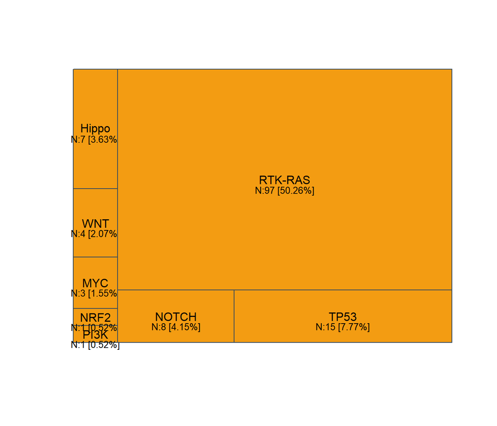

```r
pws = pathways(maf = laml, plotType = 'treemap')
```

Its also possible to visualize the results

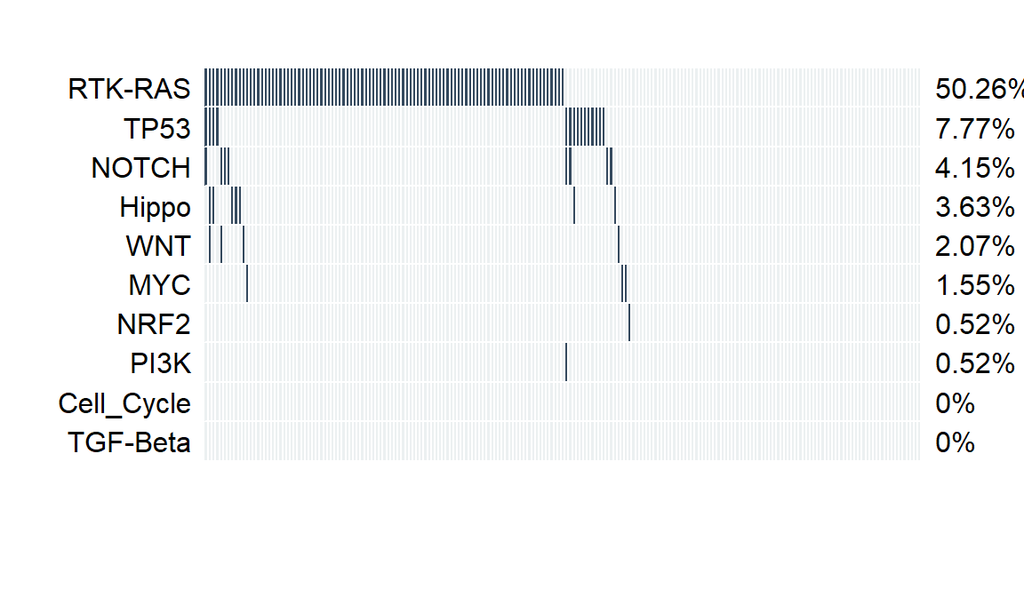

```r
plotPathways(maf = laml, pathlist = pws)
```

## 9.8 Tumor heterogeneity and MATH scores

### 9.8.1 Heterogeneity in tumor samples

Tumors are generally heterogeneous i.e, consist of multiple clones. This heterogeneity can be inferred by clustering variant allele frequencies. `inferHeterogeneity` function uses vaf information to cluster variants (using `mclust`), to infer clonality. By default, `inferHeterogeneity` function looks for column *t_vaf* containing vaf information. However, if the field name is different from *t_vaf*, we can manually specify it using argument `vafCol`. For example, in this case study vaf is stored under the field name *i_TumorVAF_WU*.

```r
#Heterogeneity in sample TCGA.AB.2972
library("mclust")
tcga.ab.2972.het = inferHeterogeneity(maf = laml, tsb = 'TCGA-AB-2972', vafCol = 'i_TumorVAF_WU')
```

```
## Processing TCGA-AB-2972..
```

```r
print(tcga.ab.2972.het$clusterMeans)
```

```
##    Tumor_Sample_Barcode cluster   meanVaf
##                  <fctr>  <char>     <num>
## 1:         TCGA-AB-2972       2 0.4496571
## 2:         TCGA-AB-2972       1 0.2454750
## 3:         TCGA-AB-2972 outlier 0.3695000
```

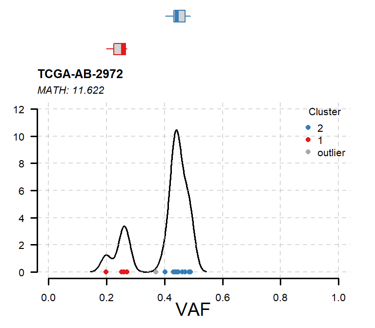

```r
#Visualizing results
plotClusters(clusters = tcga.ab.2972.het)
```

Above figure shows clear separation of two clones clustered at mean variant allele frequencies of ~45% (major clone) and another minor clone at variant allele frequency of ~25%.

Although clustering of variant allele frequencies gives us a fair idea on heterogeneity, it is also possible to measure the extent of heterogeneity in terms of a numerical value. MATH score (mentioned as a subtitle in above plot) is a simple quantitative measure of intra-tumor heterogeneity, which calculates the width of the vaf distribution. Higher MATH scores are found to be associated with poor outcome. MATH score can also be used a proxy variable for survival analysis 11.

### 9.8.2 Ignoring variants in copy number altered regions

We can use copy number information to ignore variants located on copy-number altered regions. Copy number alterations results in abnormally high/low variant allele frequencies, which tends to affect clustering. Removing such variants improves clustering and density estimation while retaining biologically meaningful results. Copy number information can be provided as a segmented file generated from segmentation programmes, such as Circular Binary Segmentation from “DNACopy” Bioconductor package 6.

```r
seg = system.file('extdata', 'TCGA.AB.3009.hg19.seg.txt', package = 'maftools')
tcga.ab.3009.het = inferHeterogeneity(maf = laml, tsb = 'TCGA-AB-3009', segFile = seg, vafCol = 'i_TumorVAF_WU')
```

```
## Processing TCGA-AB-3009..
```

```
## Removed 1 variants with no copy number data.
```

```
##    Hugo_Symbol Chromosome Start_Position End_Position Tumor_Sample_Barcode
##         <char>     <char>          <num>        <num>               <fctr>
## 1:        PHF6         23      133551224    133551224         TCGA-AB-3009
##        t_vaf Segment_Start Segment_End Segment_Mean    CN
##        <num>         <int>       <int>        <num> <num>
## 1: 0.9349112            NA          NA           NA    NA
```

```
## Copy number altered variants:
```

```
##    Hugo_Symbol Chromosome Start_Position End_Position Tumor_Sample_Barcode
##         <char>     <char>          <num>        <num>               <fctr>
## 1:     NFKBIL2          8      145668658    145668658         TCGA-AB-3009
## 2:         NF1         17       29562981     29562981         TCGA-AB-3009
## 3:       SUZ12         17       30293198     30293198         TCGA-AB-3009
##        t_vaf Segment_Start Segment_End Segment_Mean       CN    cluster
##        <num>         <int>       <int>        <num>    <num>     <char>
## 1: 0.4415584     145232496   145760746       0.3976 2.634629 CN_altered
## 2: 0.8419000      29054355    30363868      -0.9157 1.060173 CN_altered
## 3: 0.8958333      29054355    30363868      -0.9157 1.060173 CN_altered
```

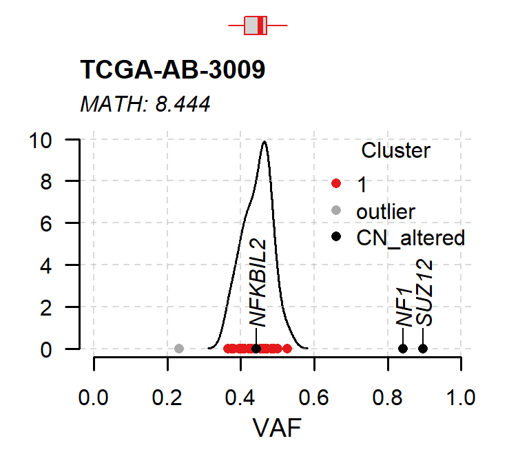

```r
#Visualizing results. Highlighting those variants on copynumber altered variants.
plotClusters(clusters = tcga.ab.3009.het, genes = 'CN_altered', showCNvars = TRUE)
```

Above figure shows two genes NF1 and SUZ12 with high VAF’s, which is due to copy number alterations (deletion). Those two genes are ignored from analysis.

## 9.9 Mutational Signatures

Every cancer, as it progresses leaves a signature characterized by specific pattern of nucleotide substitutions. [Alexandrov et.al](http://www.nature.com/nature/journal/v500/n7463/full/nature12477.html) have shown such mutational signatures, derived from over 7000 cancer samples 5. Such signatures can be extracted by decomposing matrix of nucleotide substitutions, classified into 96 substitution classes based on immediate bases surrounding the mutated base. Extracted signatures can also be compared to those [validated signatures](http://cancer.sanger.ac.uk/cosmic/signatures).

First step in signature analysis is to obtain the adjacent bases surrounding the mutated base and form a mutation matrix. NOTE: Earlier versions of maftools required a fasta file as an input. But starting from 1.8.0, BSgenome objects are used for faster sequence extraction.

```r
#Requires BSgenome object
library("BSgenome.Hsapiens.UCSC.hg19", quietly = TRUE)
laml.tnm = trinucleotideMatrix(maf = laml, prefix = 'chr', add = TRUE, ref_genome = "BSgenome.Hsapiens.UCSC.hg19")
```

```
## -Extracting 5' and 3' adjacent bases
## -Extracting +/- 20bp around mutated bases for background C>T estimation
## -Estimating APOBEC enrichment scores
## --Performing one-way Fisher's test for APOBEC enrichment
## ---APOBEC related mutations are enriched in  3.315 % of samples (APOBEC enrichment score > 2 ;  6  of  181  samples)
## -Creating mutation matrix
## --matrix of dimension 188x96
```

Above function performs two steps:

- Estimates APOBEC enrichment scores
- Prepares a mutational matrix for signature analysis.

### 9.9.1 APOBEC Enrichment estimation.

APOBEC induced mutations are more frequent in solid tumors and are mainly associated with C>T transition events occurring in TCW motif. APOBEC enrichment scores in the above command are estimated using the method described by Roberts et al 13. Briefly, enrichment of C>T mutations occurring within TCW motif over all of the C>T mutations in a given sample is compared to background Cytosines and TCWs occurring within 20bp of mutated bases.

$$\frac{n_{tCw} * background_C}{n_C *
background_{TCW}}$$

One-sided fishers exact test is also performed to statistically evaluate the enrichment score, as described in original study by Roberts et al.

### 9.9.2 Differences between APOBEC enriched and non-enriched samples

We can also analyze the differences in mutational patterns between APOBEC enriched and non-APOBEC enriched samples. `plotApobecDiff` is a function which takes APOBEC enrichment scores estimated by `trinucleotideMatrix` and classifies samples into APOBEC enriched and non-APOBEC enriched. Once stratified, it compares these two groups to identify differentially altered genes.

Note that, LAML with no APOBEC enrichments, is not an ideal cohort for this sort of analysis and hence below plot is only for demonstration purpose.

```
## -Processing clinical data
## -Processing clinical data
```

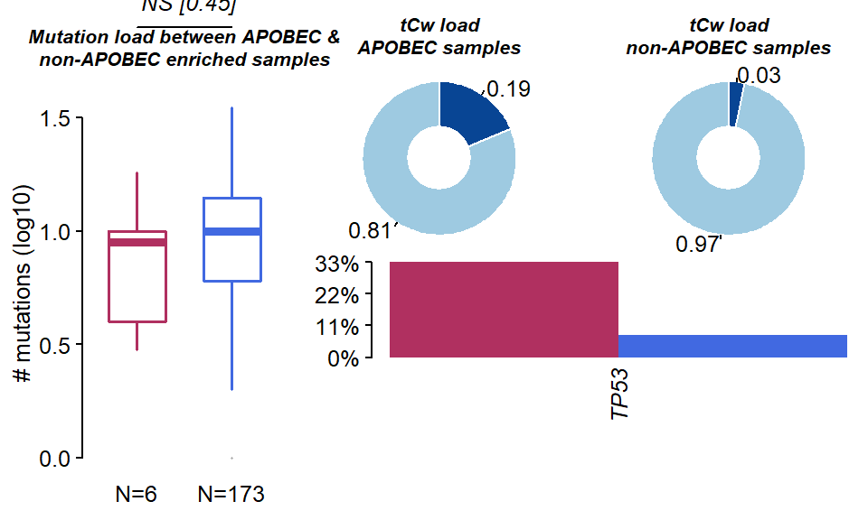

```
## $results
## Index: <Hugo_Symbol>
##      Hugo_Symbol Enriched nonEnriched       pval       or     ci.up     ci.low
##           <char>    <num>       <int>      <num>    <num>     <num>      <num>
##   1:        TP53        2          13 0.08175632 5.997646  46.60886 0.49875432
##   2:        TET2        1          16 0.45739351 1.940700  18.98398 0.03882963
##   3:        FLT3        2          45 0.65523131 1.408185  10.21162 0.12341748
##   4:      ADAM11        0           2 1.00000000 0.000000 164.19147 0.00000000
##   5:        APOB        0           2 1.00000000 0.000000 164.19147 0.00000000
##  ---
## 132:         WAC        0           2 1.00000000 0.000000 164.19147 0.00000000
## 133:         WT1        0          12 1.00000000 0.000000  12.69086 0.00000000
## 134:      ZBTB33        0           2 1.00000000 0.000000 164.19147 0.00000000
## 135:      ZC3H18        0           2 1.00000000 0.000000 164.19147 0.00000000
## 136:      ZNF687        0           2 1.00000000 0.000000 164.19147 0.00000000
##      adjPval
##        <num>
##   1:       1
##   2:       1
##   3:       1
##   4:       1
##   5:       1
##  ---
## 132:       1
## 133:       1
## 134:       1
## 135:       1
## 136:       1
##
## $SampleSummary
## Key: <Cohort>
##         Cohort SampleSize  Mean Median
##         <char>      <num> <num>  <num>
## 1:    Enriched          6 7.167    6.5
## 2: nonEnriched        172 9.715    9.0
```

```r
plotApobecDiff(tnm = laml.tnm, maf = laml, pVal = 0.2)
```